# Prediction Assignment Writeup

A. Rosa Castillo

9 October 2017

## Summary

The goal of this project is to generate a prediction model based on the data collected by the human activity recognition research. http://groupware.les.inf.puc-rio.br/har This group provides a dataset with sports activity information collected on 8 hours of activities of 6 healthy subjects (information from the website).

Read more: http://groupware.les.inf.puc-rio.br/har#ixzz4v0QJRaBg

Our purpose here it to predict the manner in which they did the exercise.

## Load the datasets

```r
url1 <- "https://d396qusza40orc.cloudfront.net/predmachlearn/pml-training.csv"
trainingData = read.csv(url1,na.strings=c('#DIV/0', '', 'NA') ,stringsAsFactors = F)

url2 <- "https://d396qusza40orc.cloudfront.net/predmachlearn/pml-testing.csv"
testData = read.csv(url2,na.strings= c('#DIV/0', '', 'NA'),stringsAsFactors = F)
```

## Exploratory Analysis

We will perform first some exploratory analysis on the datasets. We need to perfom the same transformations in both the training and the test datasets. See outputs of the ‘’’str’’’ command at the appendix of this document.

```r
library(dplyr)
str(trainingData)
str(testData)
```

There are NA values we need to clean. Let’s first decide what to do with these NA values.

```r
sum(!complete.cases(trainingData))
```

```
## [1] 19216
```

The number of incompleted cases is too high 19216, from the total 19622. Thus we cannot perfom a radical filter to eliminate all rows containing them because we would reduce too much the samples count. However we can delete the columns with such a huge number of NAs since they will be no good predictors anyway.

```r
trainingCount <-sapply(trainingData, function(y) sum(length(which(is.na(y)))))
trainingCount$name <- rownames(trainingCount)
trainingCount <- data.frame(trainingCount)
# take columns with more than 19000 NA values
columns2Delete <- trainingCount[,apply(trainingCount, MARGIN=2, function(col){any(col>19000)})]
dim(columns2Delete)
```

```
## [1]   1 100
```

```r
# we have 100 columns to delete in the training set
reducedTrainingData <- trainingData[, ! names(trainingData) %in% names(columns2Delete)]
```

We repeat the same transformation in the test set:

```r
testCount <-sapply(testData, function(y) sum(length(which(is.na(y)))))
testCount$name <- rownames(testCount)
testCount <- data.frame(testCount)
# take columns with more than 19 NA values (the total number of rows is 20)
testCols2Delete <- testCount[,apply(testCount, MARGIN=2, function(col){any(col>19)})]
reducedTestData <- testData[, ! names(testData) %in% names(testCols2Delete)]
```

By checking the classes of the dataset we still have some columns as characters.

```r
characterClasses <- names(reducedTrainingData[,sapply(reducedTrainingData,is.character)])
```

We have four columns ‘’user_name’‘,’‘cvtd_timestamp’‘,’‘new_window’‘and’‘classe’’. The second variable is a date so we transform it into the right type.

```r
reducedTrainingData$cvtd_timestamp <- as.Date(reducedTrainingData$cvtd_timestamp, "%m/%d/%Y %H:%M")
reducedTestData$cvtd_timestamp <- as.Date(reducedTestData$cvtd_timestamp, "%m/%d/%Y %H:%M")
```

The ‘’classe’’ variable is the outcome so we transform the other two into factors.

```r
# transforming character variables into factors
reducedTrainingData$user_name <- as.factor(reducedTrainingData$user_name)
reducedTestData$user_name <- as.factor(reducedTestData$user_name)
reducedTrainingData$new_window <- as.factor(reducedTrainingData$new_window)
reducedTestData$new_window <- as.factor(reducedTestData$new_window)
sum(reducedTrainingData$new_window == "no")
```

```
## [1] 19216
```

Because from 19622 observations in the training set the value ‘’no’’ is in 19216 ones, this variable is not going to bring a lot of information, but we will keep it for the moment.

### Still variables with NA values?

When we analyze our transformed datasets, both for training and test, we discover there are still some missing values at the test dataset for the timestamp column.

```r
sum(is.na(reducedTestData$cvtd_timestamp))
```

```
## [1] 12
```

We have 12 missing values from 20 observations, thus we decide not to include this variable as predictor.

## Prediction analysis

### Removing not useful predictors and preparing the datasets for the model

As we said before, let’s remove the ‘’cvtd_timestamp’‘column since we discovered it may introduce many missing values, so it does not help in our predicting model. Besides the’‘X’‘column is just the row number so we also delete it. Finally at the test dataset there is a redundant’‘problem_id’‘column which is also the same as’‘X’‘, then we remove it too. In addition we decide to remove the’‘user_name’’ , since we want to predict just based on the results of the activity.

```r
# removing not useful predictors
library(tidyverse)
finalTrainingData <- reducedTrainingData %>% select(-X, -user_name, -cvtd_timestamp)
finalTestData <- reducedTestData %>% select(-X, -user_name, -cvtd_timestamp, -problem_id)
# put the outcome as factor
finalTrainingData$classe <- as.factor(finalTrainingData$classe)
```

We will keep the ‘’’finalTestData’‘’ for the final step of the assignment project. Notice that the test dataset has no’‘classe’’ column since it is our goal to predict it.

Let’s divide the training set into two sets to check how good is our model.

```r
library(caret)
set.seed(1223)
# create training and test sets 80% for training
inTrain <- createDataPartition(y=finalTrainingData$classe,p=0.7, list=FALSE)
training <- finalTrainingData[inTrain,]
testing <- finalTrainingData[-inTrain,]
```

Let’s check briefly our predictors to check if we have Zero covariates.

```r
nearZeroVar(training,saveMetrics = TRUE)
```

```
##                      freqRatio percentUnique zeroVar   nzv
## raw_timestamp_part_1  1.033333    6.09303341   FALSE FALSE
## raw_timestamp_part_2  1.000000   89.52464148   FALSE FALSE
## new_window           47.712766    0.01455922   FALSE  TRUE
## num_window            1.033333    6.24590522   FALSE FALSE
## roll_belt             1.091772    8.15316299   FALSE FALSE
## pitch_belt            1.125984   12.27342214   FALSE FALSE
## yaw_belt              1.107649   13.08145883   FALSE FALSE
## total_accel_belt      1.075512    0.20382907   FALSE FALSE
## gyros_belt_x          1.045408    0.90995123   FALSE FALSE
## gyros_belt_y          1.128900    0.48045425   FALSE FALSE
## gyros_belt_z          1.046863    1.17929679   FALSE FALSE
## accel_belt_x          1.029144    1.16473757   FALSE FALSE
## accel_belt_y          1.103608    0.97546771   FALSE FALSE
## accel_belt_z          1.085667    2.11836646   FALSE FALSE
## magnet_belt_x         1.168776    2.22028099   FALSE FALSE
## magnet_belt_y         1.096916    2.08196841   FALSE FALSE
## magnet_belt_z         1.057751    3.17390988   FALSE FALSE
## roll_arm             47.120000   17.42010628   FALSE FALSE
## pitch_arm            81.275862   20.46298318   FALSE FALSE
## yaw_arm              32.722222   19.04345927   FALSE FALSE
## total_accel_arm       1.017187    0.47317464   FALSE FALSE
## gyros_arm_x           1.074713    4.55703574   FALSE FALSE
## gyros_arm_y           1.379310    2.67889641   FALSE FALSE
## gyros_arm_z           1.130435    1.70342870   FALSE FALSE
## accel_arm_x           1.000000    5.56162190   FALSE FALSE
## accel_arm_y           1.105263    3.81451554   FALSE FALSE
## accel_arm_z           1.086957    5.59074034   FALSE FALSE
## magnet_arm_x          1.016949    9.66732183   FALSE FALSE
## magnet_arm_y          1.065574    6.20950717   FALSE FALSE
## magnet_arm_z          1.086420    9.10679188   FALSE FALSE
## roll_dumbbell         1.081395   86.56911990   FALSE FALSE
## pitch_dumbbell        2.387097   84.17412827   FALSE FALSE
## yaw_dumbbell          1.068966   85.96491228   FALSE FALSE
## total_accel_dumbbell  1.119874    0.30574361   FALSE FALSE
## gyros_dumbbell_x      1.016548    1.69614909   FALSE FALSE
## gyros_dumbbell_y      1.381074    1.96549465   FALSE FALSE
## gyros_dumbbell_z      1.063882    1.39040547   FALSE FALSE
## accel_dumbbell_x      1.050420    3.01375846   FALSE FALSE
## accel_dumbbell_y      1.078788    3.26854481   FALSE FALSE
## accel_dumbbell_z      1.123596    2.87544588   FALSE FALSE
## magnet_dumbbell_x     1.135593    7.76006406   FALSE FALSE
## magnet_dumbbell_y     1.181102    5.98383927   FALSE FALSE
## magnet_dumbbell_z     1.029197    4.79726287   FALSE FALSE
## roll_forearm         11.000000   13.69294606   FALSE FALSE
## pitch_forearm        62.204545   18.93426512   FALSE FALSE
## yaw_forearm          14.329843   12.75387639   FALSE FALSE
## total_accel_forearm   1.102157    0.49501347   FALSE FALSE
## gyros_forearm_x       1.037940    2.10380724   FALSE FALSE
## gyros_forearm_y       1.048872    5.29227633   FALSE FALSE
## gyros_forearm_z       1.119883    2.09652763   FALSE FALSE
## accel_forearm_x       1.133333    5.69265487   FALSE FALSE
## accel_forearm_y       1.000000    7.09033996   FALSE FALSE
## accel_forearm_z       1.017241    4.02562423   FALSE FALSE
## magnet_forearm_x      1.033898   10.57727306   FALSE FALSE
## magnet_forearm_y      1.213115   13.34352479   FALSE FALSE
## magnet_forearm_z      1.047619   11.72745141   FALSE FALSE
## classe                1.469526    0.03639805   FALSE FALSE
```

As we suspected in the exploratory analysis part, we should remove the ‘new_window’ predictor since it is a poor predictor. Besides we could also remove the predictors of the timestamp columns, since if we include num_window in the model, we will capture the time ordering without having to include the timestamps.

```r
# remove predictors
training <- training %>% select(-new_window, -raw_timestamp_part_1, -raw_timestamp_part_2)
testing <- testing %>% select(-new_window, -raw_timestamp_part_1, -raw_timestamp_part_2)
# repeat these transformations in the finalTestData
finalTestData <- finalTestData %>% select(-new_window, -raw_timestamp_part_1, -raw_timestamp_part_2)
```

### Choosing a method

We choose ‘’’random forest’’’ as is one of the most used/accurate algorithms along with boosting. However when we tried to train the model with the default values, it did not end the computation. Thus we will improve the performance of the calculations using a parallel approach (as recommended by https://github.com/lgreski/datasciencectacontent/blob/master/markdown/pml-randomForestPerformance.md).

#### Configure parallel processing

```r
library(parallel)
library(doParallel)
cluster <- makeCluster(detectCores() - 1) # convention to leave 1 core for OS
registerDoParallel(cluster)
```

```r
library(caret)
rf_ctrl <- trainControl(method = "cv", number = 3, allowParallel = TRUE)
```

#### Develop training model

We will use some options of the model training process in caret to speed up the development of the model. For instance we use the principal component analysis (pca) option as preprocess. Besides we tried the model for different values of the ‘’mtry’‘parameter (rumber of variables randomly sampled as candidates at each split). The accuracy results are the best for mtry = 3. These results can be achieved by calling the’‘train’’ function in caret with newGrid = expand.grid(mtry = c(2,3,4,5,8,15))

```r
mtry  Accuracy   Kappa
   2    0.9646499  0.9552810
   3    0.9664245  0.9575428
   4    0.9643024  0.9548431
   5    0.9642253  0.9547336
   8    0.9623813  0.9524132
  15    0.9579305  0.9467849
```

```r
modelFit <- train(training[,1:53], training[,54], method = "rf",  preProcess="pca",  tuneGrid = data.frame(mtry = 3), trainControl = rf_ctrl)
```

#### De-register parallel processing cluster

```r
stopCluster(cluster)
registerDoSEQ()
```

### Sample error and accuracy

```r
modelFit
```

```
## Random Forest
##
## 13737 samples
##    53 predictor
##     5 classes: 'A', 'B', 'C', 'D', 'E'
##
## Pre-processing: principal component signal extraction (53), centered
##  (53), scaled (53)
## Resampling: Bootstrapped (25 reps)
## Summary of sample sizes: 13737, 13737, 13737, 13737, 13737, 13737, ...
## Resampling results:
##
##   Accuracy   Kappa
##   0.9653779  0.9562028
##
## Tuning parameter 'mtry' was held constant at a value of 3
```

```r
modelFit$resample
```

```
##     Accuracy     Kappa   Resample
## 1  0.9639622 0.9543924 Resample01
## 2  0.9669487 0.9581655 Resample02
## 3  0.9639338 0.9543687 Resample03
## 4  0.9604443 0.9499591 Resample04
## 5  0.9622453 0.9523014 Resample05
## 6  0.9674732 0.9587818 Resample06
## 7  0.9616987 0.9514671 Resample07
## 8  0.9655308 0.9564141 Resample08
## 9  0.9635676 0.9538935 Resample09
## 10 0.9735407 0.9665429 Resample10
## 11 0.9602895 0.9497257 Resample11
## 12 0.9674171 0.9587268 Resample12
## 13 0.9677098 0.9591373 Resample13
## 14 0.9691006 0.9609171 Resample14
## 15 0.9632499 0.9534191 Resample15
## 16 0.9667323 0.9579781 Resample16
## 17 0.9686823 0.9603837 Resample17
## 18 0.9649990 0.9557327 Resample18
## 19 0.9608993 0.9506933 Resample19
## 20 0.9627119 0.9528630 Resample20
## 21 0.9642072 0.9546372 Resample21
## 22 0.9693548 0.9613515 Resample22
## 23 0.9657086 0.9567265 Resample23
## 24 0.9655927 0.9564397 Resample24
## 25 0.9684461 0.9600515 Resample25
```

```r
confusionMatrix.train(modelFit)
```

```
## Bootstrapped (25 reps) Confusion Matrix
##
## (entries are percentual average cell counts across resamples)
##
##           Reference
## Prediction    A    B    C    D    E
##          A 28.0  0.4  0.1  0.0  0.0
##          B  0.2 18.4  0.4  0.1  0.1
##          C  0.1  0.4 16.7  0.8  0.1
##          D  0.1  0.0  0.3 15.5  0.2
##          E  0.0  0.1  0.0  0.1 18.1
##
##  Accuracy (average) : 0.9654
```

### Some plots

By plotting the final model we see there was no improvement in the error with a number of trees higher than 100. The default value in the train function is 500.

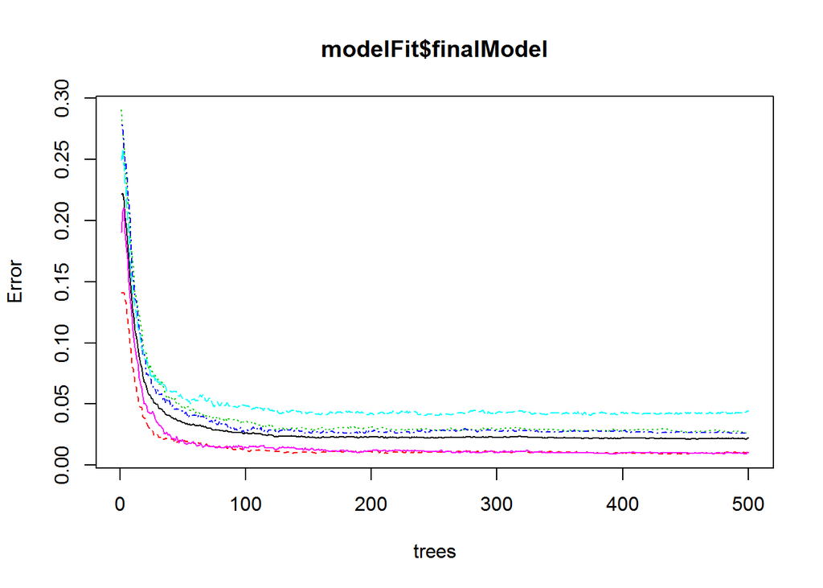

```r
plot(modelFit$finalModel)
```

Now we predict the outcome for the test data set using the random forest model and check the accuracy.

```r
library(caret)
pred <- predict(modelFit, testing)
# logic value for whether or not the rf algorithm predicted correctly
testing$predRight <- factor(pred) == testing$classe
# tabulate results
table(pred,testing$classe)
```

```
##
## pred    A    B    C    D    E
##    A 1661   12    1    4    0
##    B    4 1107   17    0    1
##    C    5   17  997   42    4
##    D    3    0   11  917    3
##    E    1    3    0    1 1074
```

```r
# print results of model
confusionMatrix(testing$classe,predict(modelFit,testing))
```

```
## Confusion Matrix and Statistics
##
##           Reference
## Prediction    A    B    C    D    E
##          A 1662    3    5    3    1
##          B   12 1107   17    0    3
##          C    1   17  997   11    0
##          D    4    0   42  917    1
##          E    0    1    4    4 1073
##
## Overall Statistics
##
##                Accuracy : 0.9781
##                  95% CI : (0.974, 0.9817)
##     No Information Rate : 0.2853
##     P-Value [Acc > NIR] : < 2.2e-16
##
##                   Kappa : 0.9723
##  Mcnemar's Test P-Value : NA
##
## Statistics by Class:
##
##                      Class: A Class: B Class: C Class: D Class: E
## Sensitivity            0.9899   0.9814   0.9362   0.9807   0.9954
## Specificity            0.9971   0.9933   0.9940   0.9905   0.9981
## Pos Pred Value         0.9928   0.9719   0.9717   0.9512   0.9917
## Neg Pred Value         0.9960   0.9956   0.9860   0.9963   0.9990
## Prevalence             0.2853   0.1917   0.1810   0.1589   0.1832
## Detection Rate         0.2824   0.1881   0.1694   0.1558   0.1823
## Detection Prevalence   0.2845   0.1935   0.1743   0.1638   0.1839
## Balanced Accuracy      0.9935   0.9873   0.9651   0.9856   0.9967
```

## Appendix

```r
str(trainingData)
```

```
## 'data.frame':    19622 obs. of  160 variables:
##  $ X                       : int  1 2 3 4 5 6 7 8 9 10 ...
##  $ user_name               : chr  "carlitos" "carlitos" "carlitos" "carlitos" ...
##  $ raw_timestamp_part_1    : int  1323084231 1323084231 1323084231 1323084232 1323084232 1323084232 1323084232 1323084232 1323084232 1323084232 ...
##  $ raw_timestamp_part_2    : int  788290 808298 820366 120339 196328 304277 368296 440390 484323 484434 ...
##  $ cvtd_timestamp          : chr  "05/12/2011 11:23" "05/12/2011 11:23" "05/12/2011 11:23" "05/12/2011 11:23" ...
##  $ new_window              : chr  "no" "no" "no" "no" ...
##  $ num_window              : int  11 11 11 12 12 12 12 12 12 12 ...
##  $ roll_belt               : num  1.41 1.41 1.42 1.48 1.48 1.45 1.42 1.42 1.43 1.45 ...
##  $ pitch_belt              : num  8.07 8.07 8.07 8.05 8.07 8.06 8.09 8.13 8.16 8.17 ...
##  $ yaw_belt                : num  -94.4 -94.4 -94.4 -94.4 -94.4 -94.4 -94.4 -94.4 -94.4 -94.4 ...
##  $ total_accel_belt        : int  3 3 3 3 3 3 3 3 3 3 ...
##  $ kurtosis_roll_belt      : chr  NA NA NA NA ...
##  $ kurtosis_picth_belt     : chr  NA NA NA NA ...
##  $ kurtosis_yaw_belt       : chr  NA NA NA NA ...
```

[output cut: 86 more lines]

```r
str(testData)
```

```
## 'data.frame':    20 obs. of  160 variables:
##  $ X                       : int  1 2 3 4 5 6 7 8 9 10 ...
##  $ user_name               : chr  "pedro" "jeremy" "jeremy" "adelmo" ...
##  $ raw_timestamp_part_1    : int  1323095002 1322673067 1322673075 1322832789 1322489635 1322673149 1322673128 1322673076 1323084240 1322837822 ...
##  $ raw_timestamp_part_2    : int  868349 778725 342967 560311 814776 510661 766645 54671 916313 384285 ...
##  $ cvtd_timestamp          : chr  "05/12/2011 14:23" "30/11/2011 17:11" "30/11/2011 17:11" "02/12/2011 13:33" ...
##  $ new_window              : chr  "no" "no" "no" "no" ...
##  $ num_window              : int  74 431 439 194 235 504 485 440 323 664 ...
##  $ roll_belt               : num  123 1.02 0.87 125 1.35 -5.92 1.2 0.43 0.93 114 ...
##  $ pitch_belt              : num  27 4.87 1.82 -41.6 3.33 1.59 4.44 4.15 6.72 22.4 ...
##  $ yaw_belt                : num  -4.75 -88.9 -88.5 162 -88.6 -87.7 -87.3 -88.5 -93.7 -13.1 ...
##  $ total_accel_belt        : int  20 4 5 17 3 4 4 4 4 18 ...
##  $ kurtosis_roll_belt      : logi  NA NA NA NA NA NA ...
##  $ kurtosis_picth_belt     : logi  NA NA NA NA NA NA ...
##  $ kurtosis_yaw_belt       : logi  NA NA NA NA NA NA ...
```

[output cut: 86 more lines]